# example notebook - bengrn

[output not shown]

```
finished
```

[output not shown]

```
Create regulons from a dataframe of enriched features.
Additional columns saved: []

Additional columns saved: []
```

```python
scenic_grn = read_h5ad('scenic_grn.h5ad')
```

```python
(scenic_grn.varp['GRN']!=0).sum(), (scenic_grn.varp['modules']!=0).sum()
```

```
(1149, 24375)
```

```python
scenic_grn.varp['GRN'] = scenic_grn.varp['modules']
```

```python
utils.metrics(scenic_grn)
```

```
{'is_connected': False, 'scale_freeness': 334990247.0}
```

```python
utils.plot_cluster(scenic_grn, stretch=5, min_dist=0.3, spread=1)
```

[output not shown]

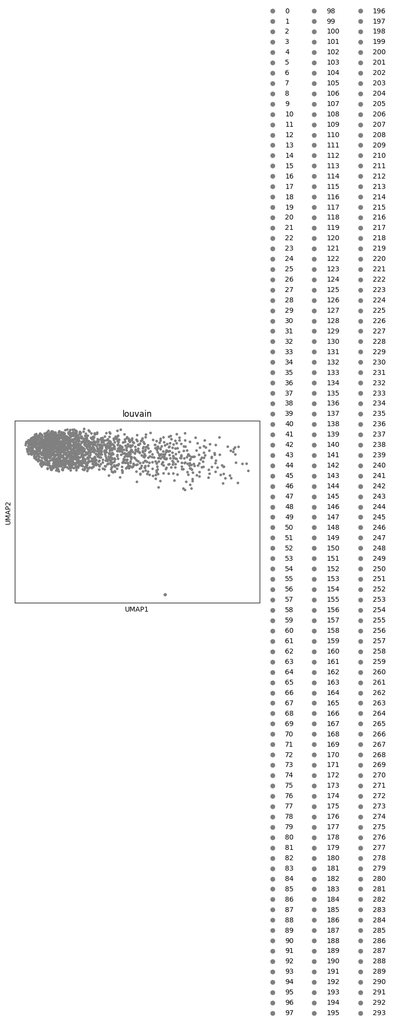

## comparisons of networks

```python
ben.BenGRN(grn).do_tests()
```

```
intersection of 999 genes
```

```
{'intersection': 0.4995,
 'precision': 0.0012519221864620907,
 'recall': 0.24455611390284757,
 'accuracy': 0.0012470993550958815,
 'spearman_corr': SignificanceResult(statistic=nan, pvalue=nan),
 'auc': 0.0015137274580689386}
```

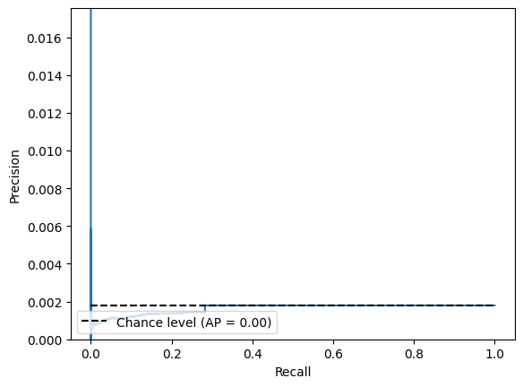

```python
ben.BenGRN(genie3_grn).do_tests()
```

```
intersection of 909 genes
```

```
{'intersection': 0.49917627677100496,
 'precision': 0.0015702927999918822,
 'recall': 0.4501818181818182,
 'accuracy': 0.001567286998354222,
 'spearman_corr': SignificanceResult(statistic=nan, pvalue=nan),
 'auc': 0.0018993308669924172}
```

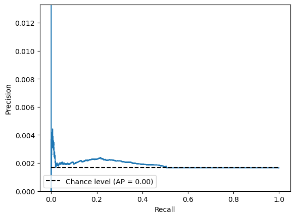

[output not shown]

```python
ben.BenGRN(scenic_grn).do_tests()
```

```
intersection of 999 genes
```

```
{'intersection': 0.4995,
 'precision': 0.06628242074927954,
 'recall': 0.02568397543271915,
 'accuracy': 0.01886018860188602,
 'spearman_corr': SignificanceResult(statistic=nan, pvalue=nan),
 'auc': 0.036774439705202534}
```

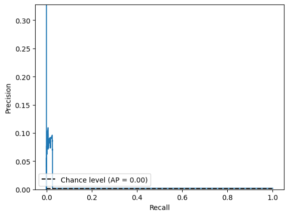

```python
scenic_grn.varp['GRN'] = scenic_grn.varp['modules']
```

```python
ben.BenGRN(scenic_grn).do_tests()
```

```
intersection of 999 genes
```

```
{'intersection': 0.4995,
 'precision': 0.021042713567839197,
 'recall': 0.14963707426018985,
 'accuracy': 0.018795146924749283,
 'spearman_corr': SignificanceResult(statistic=nan, pvalue=nan),
 'auc': 0.015585514348266173}
```

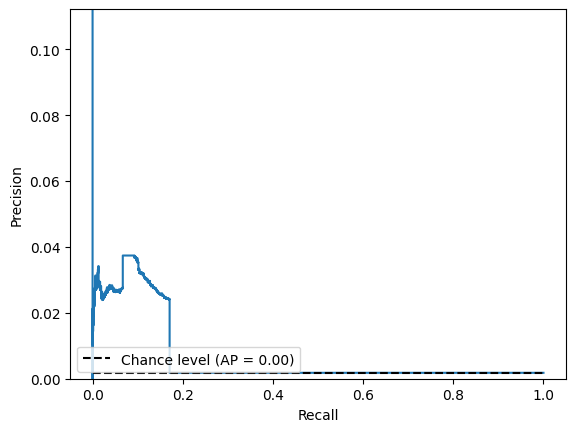

## scGPT (gene embeddings)

```python
adata = sc.read('../save/scGPT_embeddings.h5ad')
```

```python
scgpt_emb = from_embeddings(adata.T)
```

```python
ben.BenGRN(scgpt_emb).do_tests()
```

```
intersection of 6885 genes
```

```
{'intersection': 0.11343229484159019,
 'precision': 0.027964380565536635,
 'recall': 0.011714659685863875,
 'accuracy': 0.008324806994698168,
 'spearman_corr': SignificanceResult(statistic=nan, pvalue=nan),
 'auc': 0.016193328964454867}
```

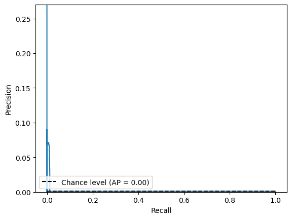